# NPQLL - Analysis

Stefanie Meliss

2024-05-07

### Study protocol

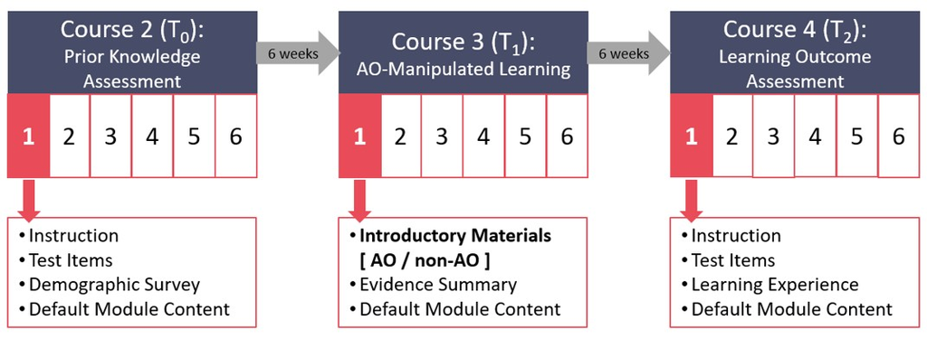

Illustration Of Planned Data Collection

### Sample size

Data collection for the project closed on October 31st 2023 at 23:59. Up to this time point, we received N = 214 responses to the prior knowledge test and N = 151 responses to the learning outcome assessment. There is complete data (i.e., pre- and post-test measures) from N = 151 participants. Upon careful inspection of the learning outcome assessment data, two participants were identified who provided non-responses in at least 14 out of 15 free-text items. Data from these two participants were excluded from the analyses. Additionally, 3 outliers were identified and removed.The sample analysed here consisted of N = 146 participants.

> Data from other participants may be excluded upon receiving the engagement data.

### Descriptive characteristics

##### Prior knowledge assessment

To assess participants’ prior knowledge on the topic of the learning material (i.e., development of reading abilities), a 10-item four-alternative forced-choice test was developed. The scope of the prior knowledge assessment was for each item to target a different construct relevant to the development of reading abilities (e.g., “An orthography is…”). For each item, the correct answer (i.e., “The set of conventions associated with a written language.”) together with three plausible distractors (e.g., “The set of conventions associated with a phonics system.”) was presented.

Participants were instructed to select the answer option that they think is correct and were encouraged to guess but discouraged from looking up the correct responses. The order of presentation of the ten items and corresponding distractors was randomised, and the same random order was applied across all participants. All items were presented on a single screen. Responses could only be submitted once each of the ten items has been completed.

Descriptives for whole sample and within each group

|  | n | mean | sd | median | trimmed | mad | min | max | range | skew | kurtosis | se |
| --- | --- | --- | --- | --- | --- | --- | --- | --- | --- | --- | --- | --- |
| all | 146 | 5.938356 | 1.801236 | 6 | 5.949153 | 1.4826 | 2 | 10 | 8 | 0.0352009 | -0.1346309 | 0.1490713 |
| AO | 73 | 5.753425 | 1.754208 | 6 | 5.745763 | 1.4826 | 2 | 10 | 8 | 0.1141677 | -0.0354832 | 0.2053145 |
| non-AO | 73 | 6.123288 | 1.840480 | 6 | 6.152542 | 1.4826 | 2 | 10 | 8 | -0.0600797 | -0.2395320 | 0.2154119 |

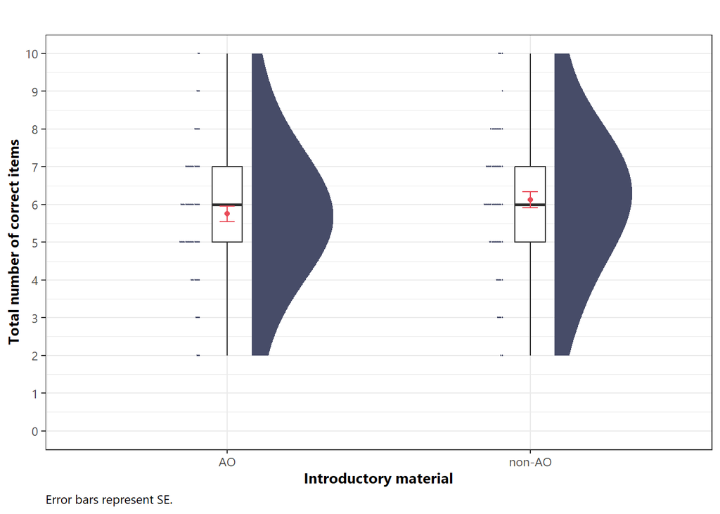

No significant difference in prior knowledge was found between the groups, t(143.67) = -1.24, p = 0.216.

##### Learning outcome assessment

To determine whether exposure to an AO facilitates learning, an expert in the field (CS) developed a learning outcome assessment for the study. The learning outcome assessment targets information presented in the learning material. We created a set of 23 items capturing knowledge retention and transfer. The resulting learning outcome assessment consisted of 15 short answer items (e.g., “Complete this sentence: The smallest chunk of meaning within a word is called a __________.”) and 8 four-alternative forced-choice items. For each presented item (e.g., “Which of these are examples of comprehension strategies that might be used by pupils to support them to build meaning from a challenging text?”), participants were instructed to select all correct answers out of four alternatives they thought as correct (e.g., “Clarifying”, “Summarising”, “Highlighting”, “Blending”).

For each of the short answer items (e.g., “Please complete the following sentence: With extensive practice, the process of word recognition develops a sense of flow. This flow of words is called __________.”), the correct solution was determined before the assessment was administered (e.g., “(reading) fluency”). Additionally, all given answers were reviewed by a rater (CS) blind to the experimental condition and alternative acceptable solutions (e.g., “prosody”, “automaticity”) were identified. For each multiple-choice item with its four answer options, the pattern of selected/unselected options was compared against the correct pattern. This means that a point was awarded if an option was correctly selected and if an option was correctly not selected. However, due to an error, one multiple-choice item was set up to be a single-choice item, i.e., only one answer option could be selected. This item was scored as if it was a single item and a point was awarded if the correct answer was selected, but not if the incorrect answers were not selected. The maximum total score on the multiple-choice items was therefore 29.

Participants were provided with matching instructions for each item type. Participants were informed that incorrect answers in the multiple-choice items will be penalised. Further, they were instructed to not look up responses. The order of presentation of the items (and corresponding distractors, in case of multiple-choice items) was randomised, and the same random order was be applied across all participants. All items will be presented on a single screen. Responses could only be submitted if each of the items has been completed.

Descriptives for whole sample and within each group

|  | n | mean | sd | median | trimmed | mad | min | max | range | skew | kurtosis | se |
| --- | --- | --- | --- | --- | --- | --- | --- | --- | --- | --- | --- | --- |
| all | 146 | 35.97260 | 3.237592 | 36 | 36.00847 | 2.9652 | 28 | 43 | 15 | -0.1487620 | -0.3066898 | 0.2679450 |
| AO | 73 | 35.61644 | 3.221586 | 36 | 35.66102 | 2.9652 | 28 | 42 | 14 | -0.0606439 | -0.3794904 | 0.3770581 |
| non-AO | 73 | 36.32877 | 3.236317 | 37 | 36.35593 | 2.9652 | 28 | 43 | 15 | -0.2410141 | -0.2412313 | 0.3787822 |

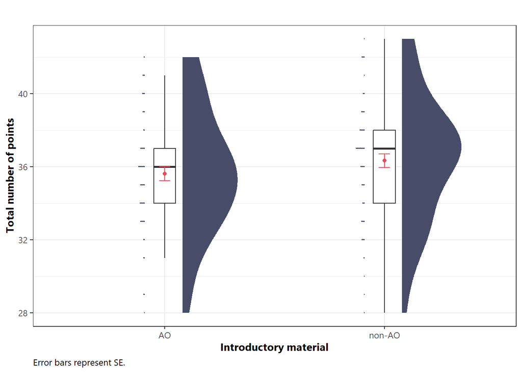

##### Change in knowledge

To determine whether there was an overall change (i.e., increase) in knowledge, scores obtained in prior knowledge and learning outcome assessment were standardised and visualised in a spaghetti plot. The plot shows that while there is no overall increase in knowledge from pre- to post-test in either of the groups, the learning patterns are highly idiosyncratic: some participants improve, some worsen, some stay the same.

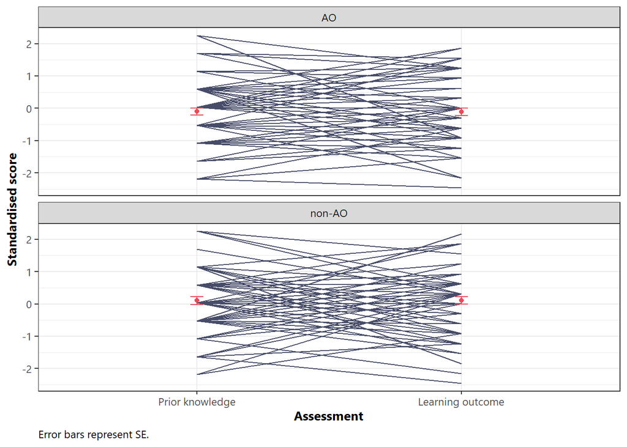

### Primary hypothesis test

Our primary hypothesis states that the exposure to an AO will improve the encoding of later presented, to-be-learned material. To test this hypothesis, an ANCOVA is used. We are interested in the main effect of experimental condition, i.e., whether an AO or historical overview, presented as introductory material, affects learning of the evidence summary (measured as the sum score of the learning outcome assessment), after controlling for prior knowledge at baseline (measured as the sum score of the prior knowledge assessment). The sum scores were standardised and the independent variable was dummy-coded (0 = “non-AO”, 1 = “AO”).

An ANCOVA was run to determine the effect of introductory material on the learning outcome assessment score after controlling for prior knowledge assessment scores.

The results are summarised as type-III analysis-of-variance table below.

|  | Row.names | Sum Sq | Df | F value | Pr(>F) | eta.sq | eta.sq.part |
| --- | --- | --- | --- | --- | --- | --- | --- |
| 2 | AO effect | 0.8478481 | 1 | 0.9468083 | 0.3321761 | 0.0058472 | 0.0065775 |
| 4 | Prior knowledge | 15.1794459 | 1 | 16.9511804 | 0.0000646 | 0.1046858 | 0.1059772 |
| 3 | Residuals | 128.0536640 | 143 | NA | NA | NA | NA |

Additionally, the results were transformed into the OLS regression output.

|  | score_posttest_c |  |  |  |  |
| --- | --- | --- | --- | --- | --- |
| Predictors | Estimates | CI | Statistic | p | df |
| Intercept | 0.08 | -0.14 – 0.30 | 0.69 | 0.491 | 143.00 |
| AO effect | -0.15 | -0.46 – 0.16 | -0.97 | 0.332 | 143.00 |
| Prior knowledge | 0.33 | 0.17 – 0.48 | 4.12 | **<0.001** | 143.00 |
| Observations | 146 |  |  |  |  |
| R<sup>2</sup> / R<sup>2</sup> adjusted | 0.117 / 0.105 |  |  |  |  |

This indicates that our primary hypothesis - that exposure to an AO (compared to a control condition) during teacher professional development ahead of new, to-be-learned material will facilitate learning of the new material - could not be confirmed. The lack of effect of introductory material is further illustrated in the figure below, plotting the mean of the learning outcome assessment score in each group, adjusted for the prior knowledge effect.

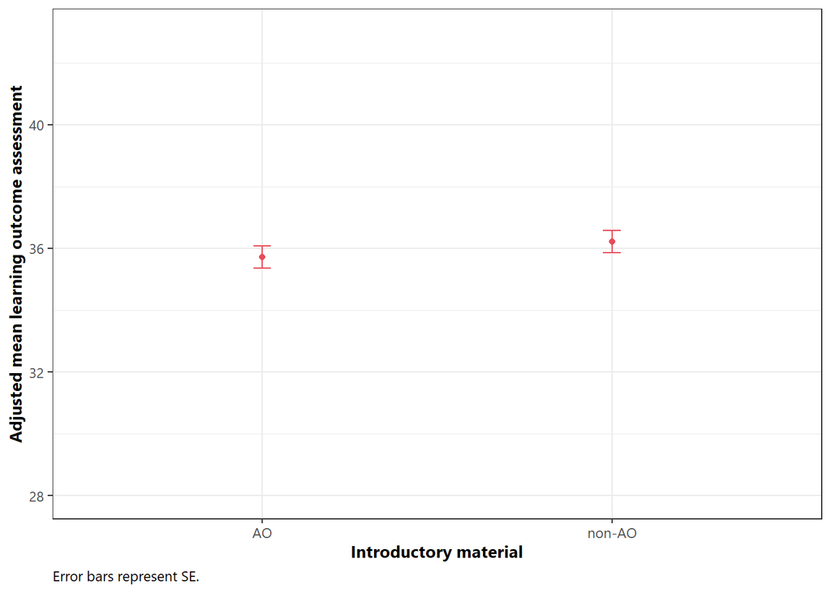

### Learning experience survey

Upon completion of the learning assessment, participants were be asked to complete a short learning experience questionnaire (Wang et al., 2021).

> The type of learning material presented did not affect the learning experience ratings.

##### Satisfaction with introductory material

To assess satisfaction with introductory material, participants were asked to rate the item ‘Overall, I was satisfied with the introductory material presented ahead of the evidence summary in module 1 of course 3 (’Learning to read’).’ on a 7-point Likert scale from 1 = ‘Strongly disagree’ to 7 = ‘Strongly agree’.

Descriptives for whole sample and within each group

|  | n | mean | sd | median | trimmed | mad | min | max | range | skew | kurtosis | se |
| --- | --- | --- | --- | --- | --- | --- | --- | --- | --- | --- | --- | --- |
| all | 145 | 5.331035 | 1.236343 | 6 | 5.478632 | 0.0000 | 1 | 7 | 6 | -1.517589 | 2.644236 | 0.1026727 |
| AO | 72 | 5.291667 | 1.271990 | 6 | 5.413793 | 1.4826 | 1 | 7 | 6 | -1.115565 | 1.025332 | 0.1499054 |
| non-AO | 73 | 5.369863 | 1.207693 | 6 | 5.542373 | 0.0000 | 1 | 7 | 6 | -1.938127 | 4.496460 | 0.1413498 |

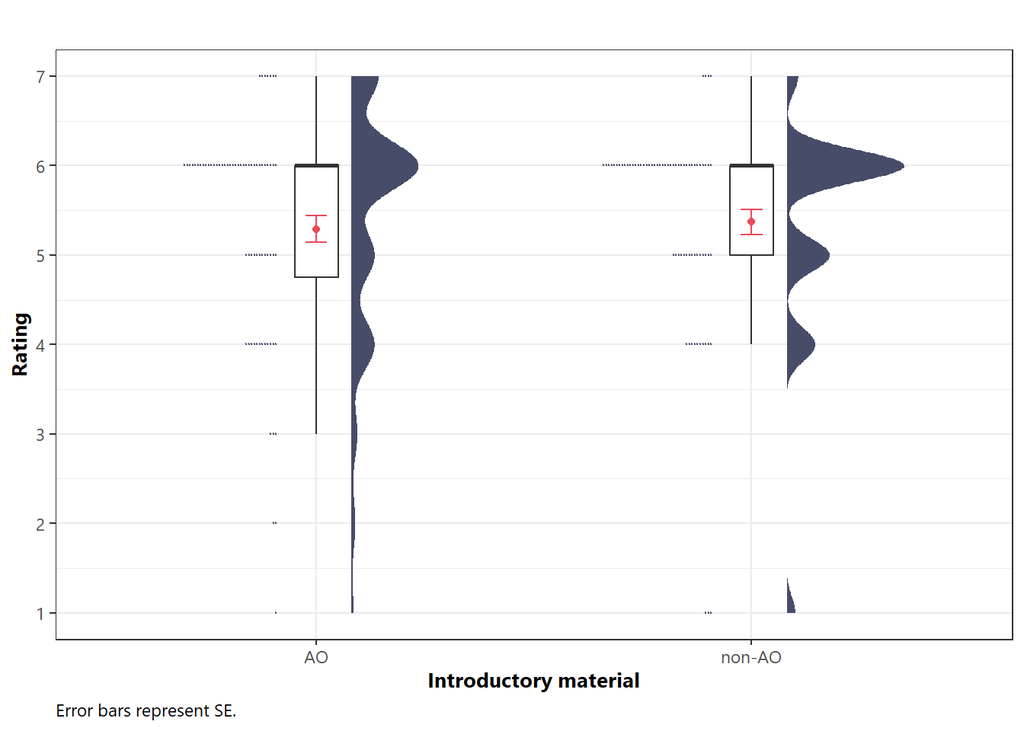

No significant difference in satisfaction with introductory material was found between the groups, t(142.39) = -0.38, p = 0.705.

##### Satisfaction with learning material

To assess satisfaction with learning material, participants were asked to rate the item ‘Overall, I was satisfied with the evidence summary presented in module 1 of course 3 (’Learning to read’).’ on a 7-point Likert scale from 1 = ‘Strongly disagree’ to 7 = ‘Strongly agree’.

Descriptives for whole sample and within each group

|  | n | mean | sd | median | trimmed | mad | min | max | range | skew | kurtosis | se |
| --- | --- | --- | --- | --- | --- | --- | --- | --- | --- | --- | --- | --- |
| all | 145 | 5.427586 | 1.141057 | 6 | 5.581197 | 0 | 1 | 7 | 6 | -1.549699 | 2.5590387 | 0.0947596 |
| AO | 72 | 5.430556 | 1.085453 | 6 | 5.568966 | 0 | 2 | 7 | 5 | -1.159841 | 0.5359354 | 0.1279219 |
| non-AO | 73 | 5.424658 | 1.200900 | 6 | 5.593220 | 0 | 1 | 7 | 6 | -1.794491 | 3.6631561 | 0.1405547 |

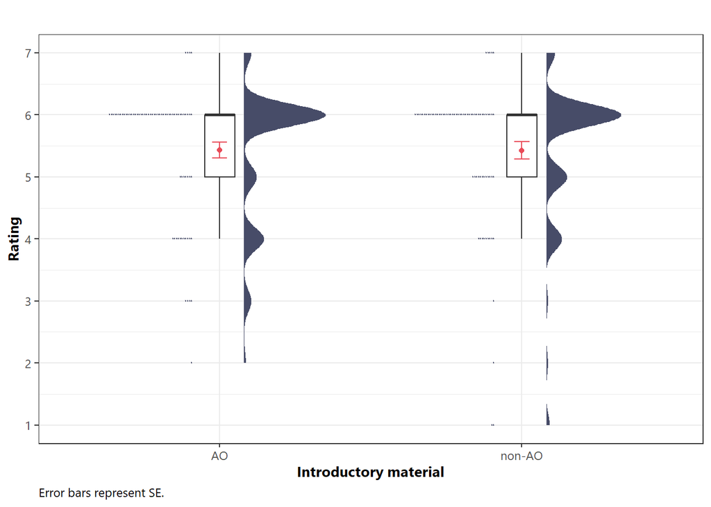

No significant difference in satisfaction with learning material was found between the groups, t(141.93) = 0.03, p = 0.975.

##### Effort

To assess effort, participants were asked to rate the item ‘How much mental effort did you invest to learn the content from the introductory material and evidence summary presented in module 1 of course 3 (’Learning to read’)?’ on a 7-point Likert scale from 1 = ‘Very, very low mental effort’ to 7 = ‘Very, very high mental effort’.

Descriptives for whole sample and within each group

|  | n | mean | sd | median | trimmed | mad | min | max | range | skew | kurtosis | se |
| --- | --- | --- | --- | --- | --- | --- | --- | --- | --- | --- | --- | --- |
| all | 145 | 4.841379 | 0.9104018 | 5 | 4.863248 | 0.0000 | 2 | 7 | 5 | -0.3987324 | 1.2687763 | 0.0756048 |
| AO | 72 | 4.888889 | 0.8145777 | 5 | 4.862069 | 0.0000 | 2 | 7 | 5 | -0.1078609 | 2.1303639 | 0.0959989 |
| non-AO | 73 | 4.794520 | 0.9994291 | 5 | 4.864407 | 1.4826 | 2 | 7 | 5 | -0.4944598 | 0.5016073 | 0.1169743 |

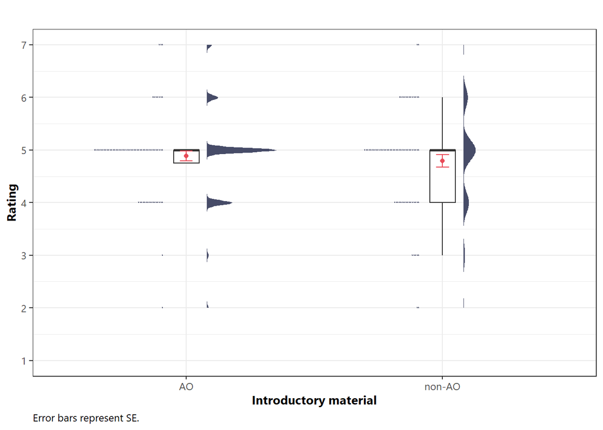

No significant difference in effort was found between the groups, t(138.11) = 0.62, p = 0.534.

##### Difficulty

To assess difficulty, participants were asked to rate the item ‘How difficult was it for you to learn the content from the introductory material and evidence summary presented in module 1 of course 3 (’Learning to read’)?’ on a 7-point Likert scale from 1 = ‘Very, very easy’ to 7 = ‘Very, very difficult’.

Descriptives for whole sample and within each group

|  | n | mean | sd | median | trimmed | mad | min | max | range | skew | kurtosis | se |
| --- | --- | --- | --- | --- | --- | --- | --- | --- | --- | --- | --- | --- |
| all | 145 | 4.255172 | 0.7243705 | 4 | 4.273504 | 0 | 2 | 7 | 5 | 0.3402021 | 1.2014261 | 0.0601557 |
| AO | 72 | 4.236111 | 0.6606240 | 4 | 4.241379 | 0 | 3 | 7 | 4 | 0.8721149 | 2.7835965 | 0.0778553 |
| non-AO | 73 | 4.273973 | 0.7863466 | 4 | 4.288136 | 0 | 2 | 6 | 4 | -0.0026328 | 0.2116321 | 0.0920349 |

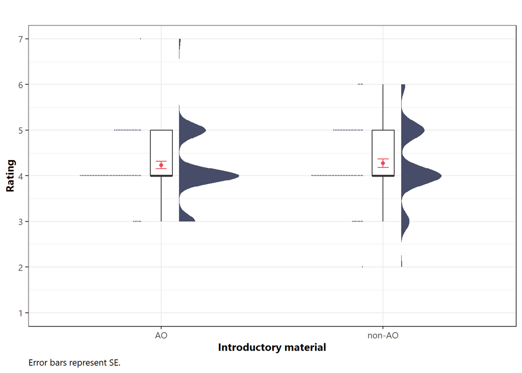

No significant difference in difficulty was found between the groups, t(139.48) = -0.31, p = 0.754.